# Pemodelan ARIMA Musiman - Peramalan Beban Listrik Harian 2021

## Packages

```r
library(ggplot2)
library(readxl)
library(tseries)
library(MASS)
library(forecast)
library(TSA)
library(TTR)
library(aTSA)
library(graphics)
```

## Data Beban Listrik

### Impor Data

Data yang digunakan adalah data **beban listrik harian** (satuan MW) dari 1 Januari sampai 31 Desember 2021 sehingga terdapat 365 pengamatan.

```r
data.energi <- read_excel("C:\\Users\\62895\\Downloads\\Data Energi 2021 (data kelompok) (1).xlsx", sheet = "Data")
data.energi$Tanggal <- as.Date(data.energi$Tanggal)

head(data.energi, 10)
```

```
## # A tibble: 10 × 4
##    Tanggal    Hari  Periode Beban_Listrik
##    <date>     <chr>   <dbl>         <dbl>
##  1 2021-01-01 Jum         1        45717.
##  2 2021-01-02 Sab         2        48892.
##  3 2021-01-03 Min         3        50647.
##  4 2021-01-04 Sen         4        61716.
##  5 2021-01-05 Sel         5        63290.
##  6 2021-01-06 Rab         6        60524.
##  7 2021-01-07 Kam         7        63531.
##  8 2021-01-08 Jum         8        62568.
##  9 2021-01-09 Sab         9        55322.
## 10 2021-01-10 Min        10        54047.
```

```r
summary(data.energi$Beban_Listrik)
```

```
##    Min. 1st Qu.  Median    Mean 3rd Qu.    Max.
##   44072   54005   57884   57603   62540   70036
```

Beban listrik harian berkisar antara 44.072 MW sampai 70.036 MW dengan rata-rata sekitar 57.603 MW. Hanya peubah `Beban_Listrik` yang dimodelkan.

```r
beban   <- data.energi$Beban_Listrik
n       <- length(beban)
```

### Pembagian Data Latih dan Data Uji

Data dibagi menjadi data latih dan data uji dengan proporsi 80:20. Data latih terdiri dari 292 hari pertama (1 Januari - 19 Oktober 2021) dan data uji terdiri dari 73 hari terakhir (20 Oktober - 31 Desember 2021).

```r
n.train <- round(0.8 * n)
train   <- beban[1:n.train]
test    <- beban[(n.train + 1):n]

# Data latih dibuat sebagai objek ts dengan periode musiman m = 7 (mingguan)
train.ts <- ts(train, frequency = 7)

c(n.train = length(train), n.test = length(test))
```

```
## n.train  n.test
##     292      73
```

### Eksplorasi Data

#### Plot Data Penuh

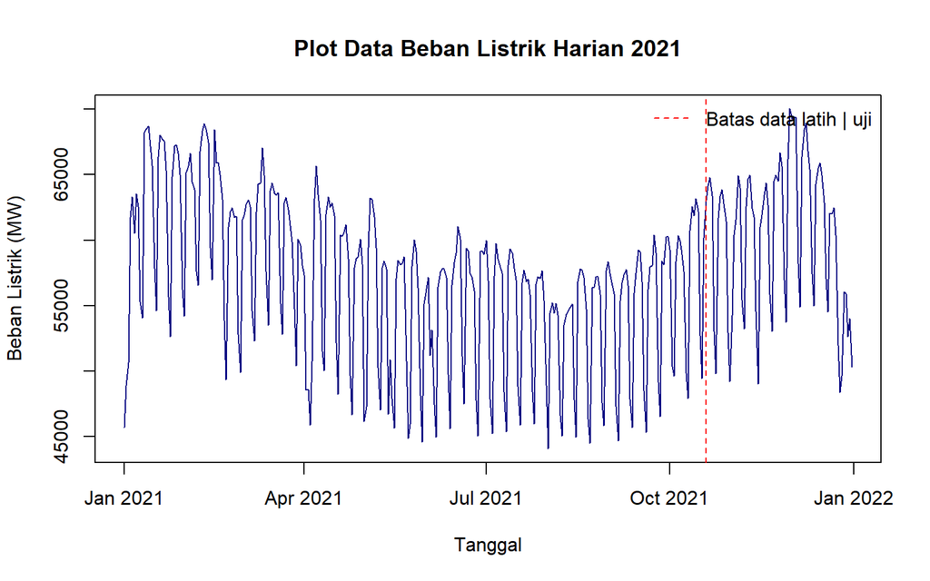

```r
plot(data.energi$Tanggal, beban,
     type = "l", col = "navyblue", lwd = 1,
     xlab = "Tanggal", ylab = "Beban Listrik (MW)",
     main = "Plot Data Beban Listrik Harian 2021")
abline(v = data.energi$Tanggal[n.train], col = "red", lty = 2)
legend("topright", legend = "Batas data latih | uji",
       col = "red", lty = 2, bty = "n")
```

Berdasarkan plot deret waktu, data beban listrik memiliki pola naik turun yang berulang dan rapat yang mengindikasikan adanya **pola musiman mingguan** (beban cenderung turun pada akhir pekan dan naik pada hari kerja). Selain itu, terlihat pula pergerakan tingkat beban jangka panjang, yaitu relatif tinggi pada awal tahun, menurun hingga pertengahan tahun, dan kembali naik pada akhir tahun.

#### Plot Data Latih

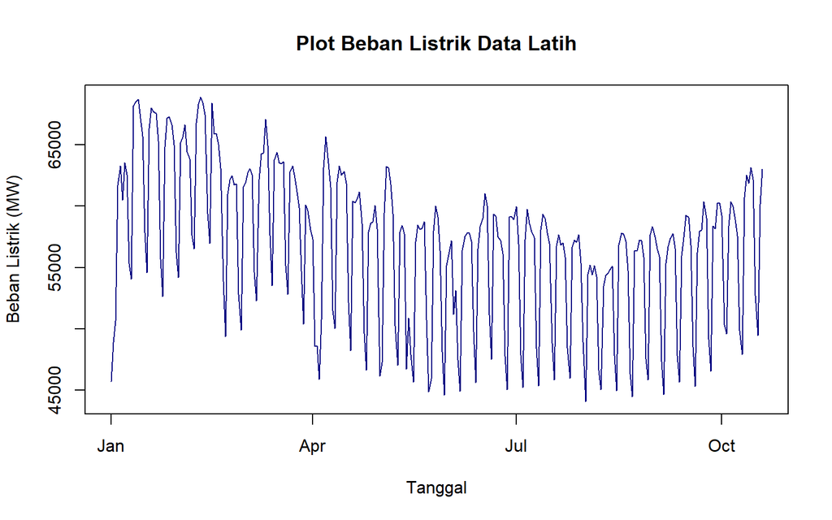

```r
plot(data.energi$Tanggal[1:n.train], train,
     type = "l", col = "navyblue",
     xlab = "Tanggal", ylab = "Beban Listrik (MW)",
     main = "Plot Beban Listrik Data Latih")
```

#### Plot Data Uji

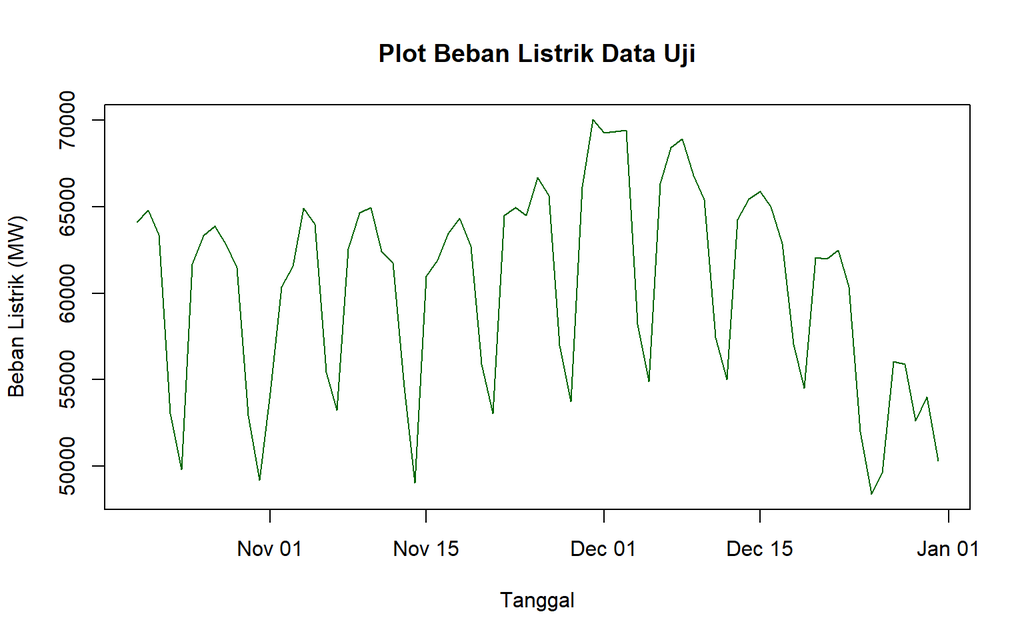

```r
plot(data.energi$Tanggal[(n.train + 1):n], test,
     type = "l", col = "darkgreen",
     xlab = "Tanggal", ylab = "Beban Listrik (MW)",
     main = "Plot Beban Listrik Data Uji")
```

Data uji mencakup periode Oktober sampai Desember. Terlihat tingkat beban cenderung naik memasuki musim dingin lalu turun tajam pada akhir Desember (kemungkinan terkait libur akhir tahun). Pola ini tidak seluruhnya terekam di data latih, sehingga akan berdampak pada akurasi.

### Uji Stasioneritas Data

#### Plot ACF

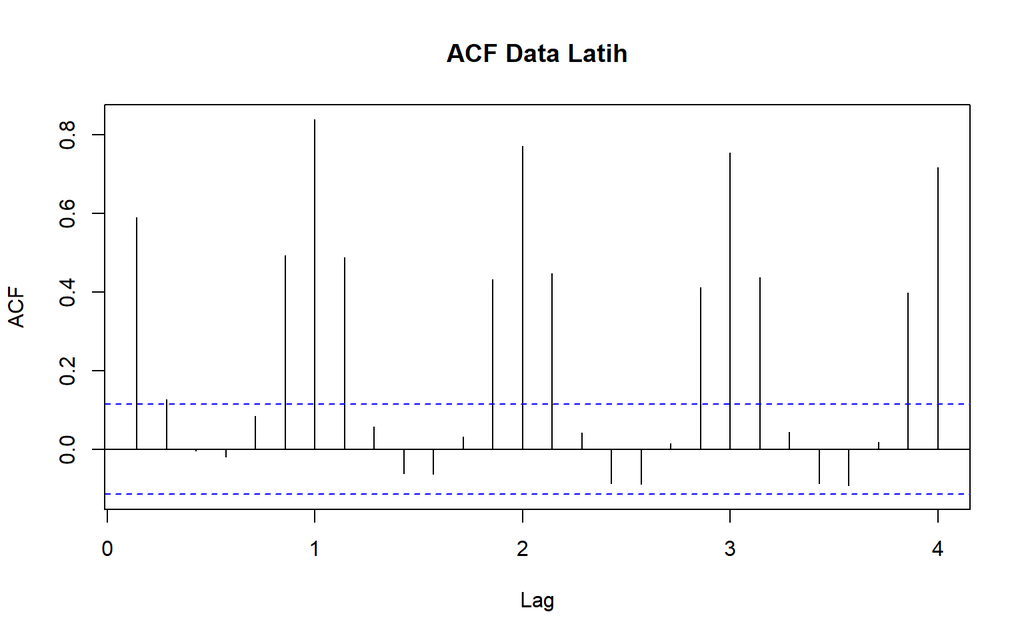

```r
acf(train.ts, lag.max = 28, main = "ACF Data Latih")
```

Plot ACF menurun sangat lambat dan berpola gelombang dengan puncak pada *lag* kelipatan 7 (7, 14, 21, 28). Hal ini menjadi indikasi bahwa data tidak stasioner dalam rataan dan mengandung pola musiman mingguan.

#### Uji ADF

```r
tseries::adf.test(train.ts)
```

```
##
##  Augmented Dickey-Fuller Test
##
## data:  train.ts
## Dickey-Fuller = -1.3637, Lag order = 6, p-value = 0.8443
## alternative hypothesis: stationary
```

$H_0$ : Data tidak stasioner dalam rataan  
$H_1$ : Data stasioner dalam rataan

Berdasarkan uji ADF tersebut, didapat *p-value* sebesar 0.8443 yang lebih besar dari taraf nyata 5% sehingga tak tolak $H_0$ dan menandakan bahwa data tidak stasioner dalam rataan. Hal ini sesuai dengan hasil eksplorasi menggunakan plot deret waktu dan plot ACF, sehingga ketidakstasioneran harus ditangani sebelum pemodelan.

#### Plot Box-Cox

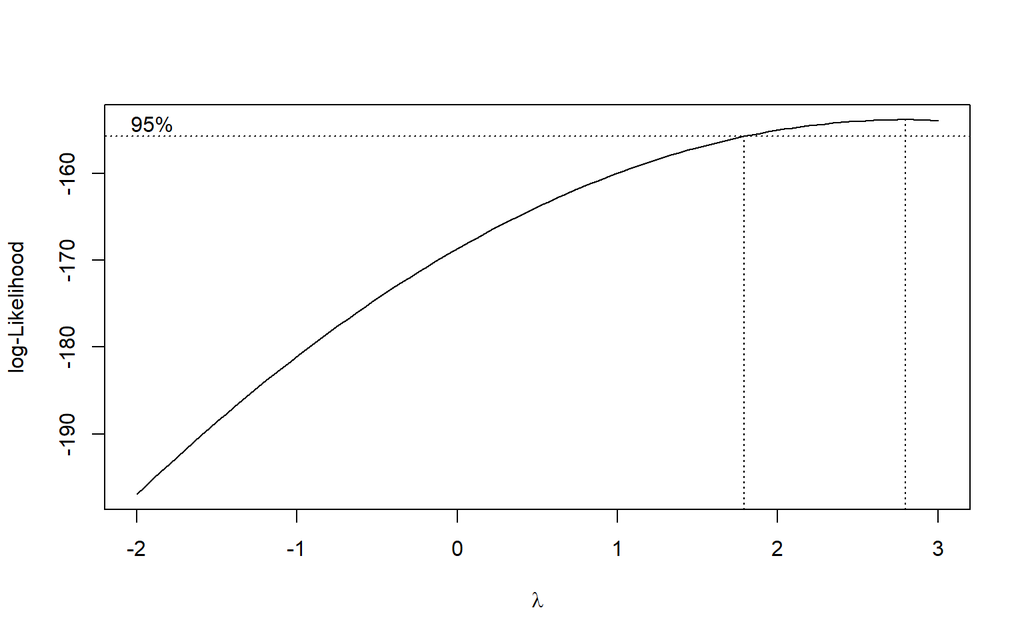

```r
index <- seq(1:length(train))

# Box-Cox
bc <- boxcox(train ~ index, lambda = seq(-2, 3, by = 0.1))
```

```r
# Nilai lambda optimum
lambda <- bc$x[which.max(bc$y)]
lambda
```

```
## [1] 2.79798
```

```r
# Selang kepercayaan 95% untuk lambda
ci_lambda <- bc$x[bc$y > max(bc$y) - 0.5 * qchisq(0.95, 1)]

# Batas bawah dan batas atas
ci_lower <- min(ci_lambda)
ci_upper <- max(ci_lambda)

c(Batas_Bawah = ci_lower, Batas_Atas = ci_upper)
```

```
## Batas_Bawah  Batas_Atas
##    1.838384    3.000000
```

Uji Box-Cox pada model regresi terhadap waktu menghasilkan $\lambda$ optimum sebesar 2,8 dengan selang kepercayaan 95%
$$1,8; 3,0$$
yang tidak memuat nilai satu. Namun, hasil ini perlu dilihat hati-hati karena nilai optimumnya berada di ujung rentang yang dicoba dan model regresi terhadap waktu tidak memperhitungkan pola musiman mingguan, sehingga sisaannya terkontaminasi oleh pola tersebut. Oleh karena itu, dilakukan pemeriksaan tambahan yang memperhitungkan periode musiman.

```r
# Metode Guerrero (memperhitungkan periode musiman)
BoxCox.lambda(train.ts, method = "guerrero")
```

```
## [1] 1.04264
```

Metode Guerrero menghasilkan $\lambda \approx 1,04$ yang sangat dekat dengan satu. Dengan demikian data dapat dianggap **stasioner dalam ragam** dan tidak diperlukan transformasi.

### Penanganan Ketidakstasioneran Data

Data tidak stasioner dalam rataan dan memiliki pola musiman mingguan, sehingga dilakukan *differencing* musiman dengan *lag* 7 ($D = 1$, $m = 7$).

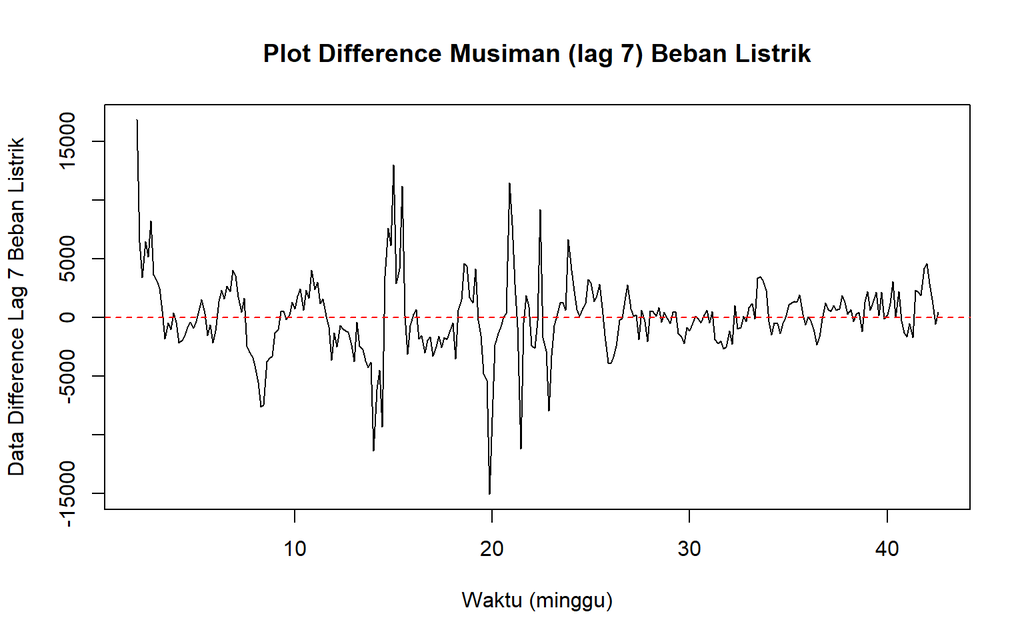

```r
# Differencing musiman lag 7
train.d7 <- diff(train.ts, lag = 7)

plot.ts(train.d7, lty = 1, xlab = "Waktu (minggu)",
        ylab = "Data Difference Lag 7 Beban Listrik",
        main = "Plot Difference Musiman (lag 7) Beban Listrik")
abline(h = 0, col = "red", lty = 2)
```

Berdasarkan plot deret waktu, terlihat bahwa data hasil *differencing* sudah bergerak di sekitar nilai tengah nol, tidak terlihat lagi tren maupun pola gerigi mingguan yang dominan.

#### Plot ACF

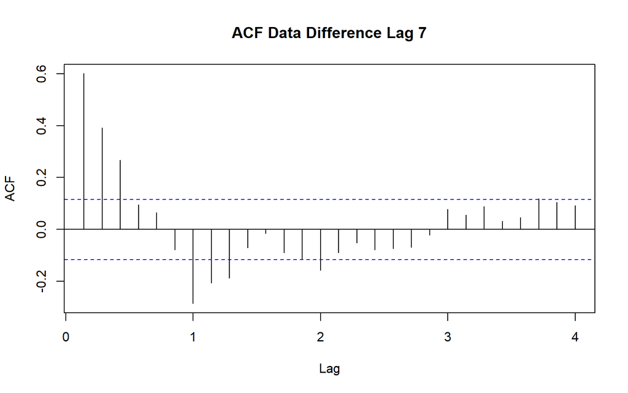

```r
acf(train.d7, lag.max = 28, main = "ACF Data Difference Lag 7")
```

Plot ACF sudah tidak menurun lambat pada *lag* kelipatan 7 seperti sebelumnya, sehingga ketidakstasioneran akibat pola musiman telah berhasil ditangani.

#### Uji ADF

```r
tseries::adf.test(train.d7)
```

```
##
##  Augmented Dickey-Fuller Test
##
## data:  train.d7
## Dickey-Fuller = -8.7514, Lag order = 6, p-value = 0.01
## alternative hypothesis: stationary
```

$H_0$ : Data tidak stasioner dalam rataan  
$H_1$ : Data stasioner dalam rataan

Berdasarkan uji ADF tersebut, didapat *p-value* sebesar 0.01 yang lebih kecil dari taraf nyata 5% sehingga tolak $H_0$ dan menandakan bahwa data stasioner dalam rataan. Hal ini sesuai dengan hasil eksplorasi menggunakan plot deret waktu dan plot ACF, sehingga ketidakstasioneran sudah berhasil ditangani dan dapat dilanjutkan ke pemodelan.

Dengan demikian orde *differencing* yang digunakan adalah $d = 0$ dan $D = 1$ dengan $m = 7$.

### Identifikasi Model

#### Plot ACF

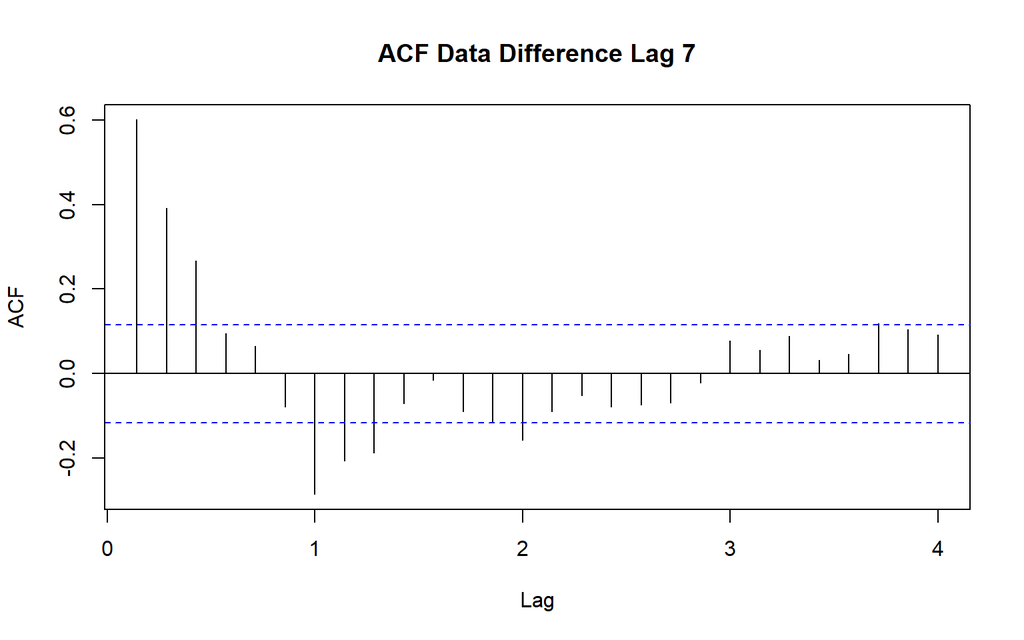

```r
acf(train.d7, lag.max = 28, main = "ACF Data Difference Lag 7")
```

#### Plot PACF

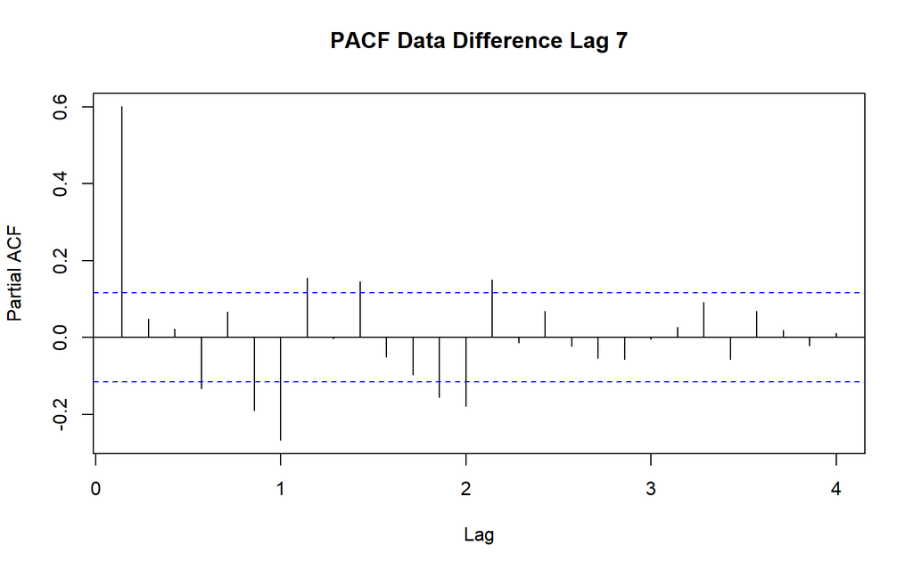

```r
pacf(train.d7, lag.max = 28, main = "PACF Data Difference Lag 7")
```

Plot PACF cenderung *cuts off* setelah *lag* 1 dan terdapat nilai signifikan pada *lag* musiman 7. Jika plot ACF dianggap *tails off*, maka model tentatifnya adalah ARIMA(1,0,0)(0,1,1)$_7$. Jika ACF dianggap *cuts off* pada *lag* 3, maka model tentatifnya adalah ARIMA(0,0,3)(0,1,1)$_7$. Jika keduanya dianggap *tails off*, maka model tentatifnya adalah ARIMA(1,0,1)(0,1,1)$_7$.

#### Plot EACF

```r
eacf(train.d7, ar.max = 7, ma.max = 13)
```

```
## AR/MA
##   0 1 2 3 4 5 6 7 8 9 10 11 12 13
## 0 x x x o o o x x x o o  o  o  x
## 1 o o x x o o x o x o o  o  o  x
## 2 x o x o o o x x x o o  o  o  x
## 3 x x x o o o x o x o x  o  o  x
## 4 x x x o o x x o x o x  o  o  x
## 5 x x x o o x x o o o o  o  o  o
## 6 x x x x x x x x o o o  x  o  o
## 7 x x x x o x x x o o o  o  o  o
```

Karena masih terdapat sisa pengaruh musiman, segitiga yang terbentuk tidak terlalu tegas. Salah satu ujung segitiga yang dapat diambil adalah ARIMA(2,0,3)(0,1,1)$_7$. Dengan demikian, terdapat empat model tentatif yang akan diduga parameternya.

### Pendugaan Parameter Model Tentatif

#### ARIMA(1,0,0)(0,1,1)$_7$

```r
model1 <- Arima(train.ts, order = c(1,0,0),
                seasonal = list(order = c(0,1,1), period = 7), method = "ML")
summary(model1)
```

```
## Series: train.ts
## ARIMA(1,0,0)(0,1,1)[7]
##
## Coefficients:
##          ar1     sma1
##       0.8704  -0.9466
## s.e.  0.0470   0.0598
##
## sigma^2 = 4186344:  log likelihood = -2584.29
## AIC=5174.58   AICc=5174.67   BIC=5185.54
##
## Training set error measures:
##                     ME     RMSE      MAE        MPE     MAPE      MASE
## Training set -115.5102 2014.277 1259.407 -0.3537623 2.270504 0.5768789
##                    ACF1
## Training set -0.1422584
```

```r
lmtest::coeftest(model1)
```

```
##
## z test of coefficients:
##
##       Estimate Std. Error z value  Pr(>|z|)
## ar1   0.870413   0.046971  18.531 < 2.2e-16 ***
## sma1 -0.946634   0.059848 -15.817 < 2.2e-16 ***
## ---
## Signif. codes:  0 '***' 0.001 '**' 0.01 '*' 0.05 '.' 0.1 ' ' 1
```

#### ARIMA(0,0,3)(0,1,1)$_7$

```r
model2 <- Arima(train.ts, order = c(0,0,3),
                seasonal = list(order = c(0,1,1), period = 7), method = "ML")
summary(model2)
```

```
## Series: train.ts
## ARIMA(0,0,3)(0,1,1)[7]
##
## Coefficients:
##          ma1     ma2     ma3     sma1
##       0.7417  0.4448  0.2963  -0.7482
## s.e.  0.0632  0.0633  0.0572   0.0507
##
## sigma^2 = 4777924:  log likelihood = -2597.15
## AIC=5204.31   AICc=5204.52   BIC=5222.57
##
## Training set error measures:
##                     ME     RMSE      MAE        MPE     MAPE     MASE
## Training set -65.20771 2144.279 1383.601 -0.2623096 2.464158 0.633767
##                      ACF1
## Training set -0.003190616
```

```r
lmtest::coeftest(model2)
```

```
##
## z test of coefficients:
##
##       Estimate Std. Error  z value  Pr(>|z|)
## ma1   0.741653   0.063230  11.7294 < 2.2e-16 ***
## ma2   0.444769   0.063282   7.0284 2.089e-12 ***
## ma3   0.296320   0.057178   5.1824 2.190e-07 ***
## sma1 -0.748237   0.050704 -14.7569 < 2.2e-16 ***
## ---
## Signif. codes:  0 '***' 0.001 '**' 0.01 '*' 0.05 '.' 0.1 ' ' 1
```

#### ARIMA(1,0,1)(0,1,1)$_7$

```r
model3 <- Arima(train.ts, order = c(1,0,1),
                seasonal = list(order = c(0,1,1), period = 7), method = "ML")
summary(model3)
```

```
## Series: train.ts
## ARIMA(1,0,1)(0,1,1)[7]
##
## Coefficients:
##          ar1      ma1     sma1
##       0.9335  -0.2174  -0.9996
## s.e.  0.0289   0.0913   0.1422
##
## sigma^2 = 3992077:  log likelihood = -2581.76
## AIC=5171.53   AICc=5171.67   BIC=5186.14
##
## Training set error measures:
##                     ME     RMSE      MAE        MPE     MAPE      MASE
## Training set -69.70425 1963.508 1251.967 -0.2756966 2.256499 0.5734712
##                     ACF1
## Training set -0.03067275
```

```r
lmtest::coeftest(model3)
```

```
##
## z test of coefficients:
##
##       Estimate Std. Error z value  Pr(>|z|)
## ar1   0.933488   0.028930 32.2676 < 2.2e-16 ***
## ma1  -0.217442   0.091332 -2.3808   0.01728 *
## sma1 -0.999622   0.142204 -7.0295 2.073e-12 ***
## ---
## Signif. codes:  0 '***' 0.001 '**' 0.01 '*' 0.05 '.' 0.1 ' ' 1
```

#### ARIMA(2,0,3)(0,1,1)$_7$

```r
model4 <- Arima(train.ts, order = c(2,0,3),
                seasonal = list(order = c(0,1,1), period = 7), method = "ML")
summary(model4)
```

```
## Series: train.ts
## ARIMA(2,0,3)(0,1,1)[7]
##
## Coefficients:
##          ar1     ar2     ma1      ma2      ma3     sma1
##       0.4758  0.4692  0.2790  -0.3463  -0.0665  -1.0000
## s.e.  0.4657  0.4513  0.4673   0.1170   0.1461   0.0544
##
## sigma^2 = 3875361:  log likelihood = -2575.66
## AIC=5165.31   AICc=5165.72   BIC=5190.88
##
## Training set error measures:
##                     ME     RMSE      MAE        MPE    MAPE     MASE
## Training set -30.94673 1924.273 1228.232 -0.1911139 2.20594 0.562599
##                     ACF1
## Training set -0.06877332
```

```r
lmtest::coeftest(model4)
```

```
##
## z test of coefficients:
##
##       Estimate Std. Error  z value  Pr(>|z|)
## ar1   0.475835   0.465673   1.0218  0.306865
## ar2   0.469244   0.451307   1.0397  0.298459
## ma1   0.278984   0.467318   0.5970  0.550515
## ma2  -0.346344   0.117033  -2.9594  0.003083 **
## ma3  -0.066523   0.146111  -0.4553  0.648899
## sma1 -0.999976   0.054438 -18.3690 < 2.2e-16 ***
## ---
## Signif. codes:  0 '***' 0.001 '**' 0.01 '*' 0.05 '.' 0.1 ' ' 1
```

### Ringkasan AIC

```r
model_tentatif <- data.frame(
  Model = c("ARIMA(1,0,0)(0,1,1)[7]",
            "ARIMA(0,0,3)(0,1,1)[7]",
            "ARIMA(1,0,1)(0,1,1)[7]",
            "ARIMA(2,0,3)(0,1,1)[7]"),
  AIC = c(AIC(model1), AIC(model2), AIC(model3), AIC(model4)),
  BIC = c(BIC(model1), BIC(model2), BIC(model3), BIC(model4)),
  Semua_Parameter_Signifikan = c("Ya", "Ya", "Ya", "Tidak")
)
model_tentatif
```

```
##                    Model      AIC      BIC Semua_Parameter_Signifikan
## 1 ARIMA(1,0,0)(0,1,1)[7] 5174.584 5185.541                         Ya
## 2 ARIMA(0,0,3)(0,1,1)[7] 5204.307 5222.570                         Ya
## 3 ARIMA(1,0,1)(0,1,1)[7] 5171.527 5186.137                         Ya
## 4 ARIMA(2,0,3)(0,1,1)[7] 5165.312 5190.880                      Tidak
```

Model ARIMA(2,0,3)(0,1,1)$_7$ memiliki AIC terkecil, tetapi sebagian besar parameternya tidak signifikan sehingga tidak dipilih. Di antara model yang seluruh parameternya signifikan, AIC terkecil dimiliki oleh model ARIMA(1,0,1)(0,1,1)$_7$ sehingga model inilah yang dipilih untuk diperiksa lebih lanjut. Catatan: koefisien MA musiman (`sma1`) bernilai sangat dekat dengan -1. Hal ini menandakan pola mingguan pada data sangat stabil sepanjang tahun (mendekati deterministik), dan akan dibahas kembali pada bagian kesimpulan.

### Analisis Sisaan

Model terbaik hasil identifikasi kemudian dicek asumsi sisaannya. Sisaan model harus memenuhi asumsi normalitas, kebebasan, kehomogenan ragam, dan nilai tengah nol. Diagnostik model dilakukan secara eksplorasi dan uji formal.

#### Eksplorasi Sisaan

```r
sisaan <- as.numeric(model3$residuals)

par(mfrow = c(2,2))
car::qqPlot(sisaan, ylab = "Sisaan")
```

```
## [1] 133 144
```

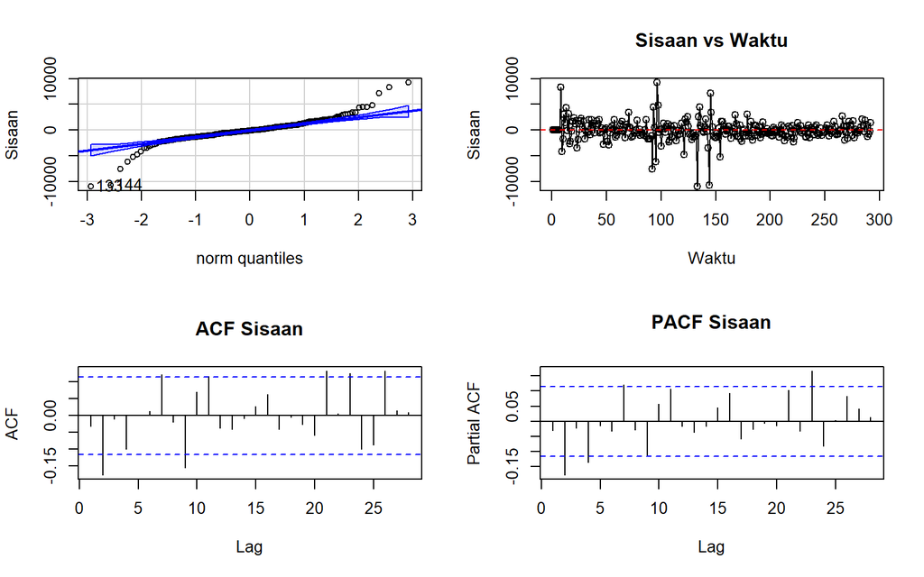

```r
plot(c(1:length(sisaan)), sisaan, type = "o",
     xlab = "Waktu", ylab = "Sisaan", main = "Sisaan vs Waktu")
abline(h = 0, col = "red", lty = 2)
acf(sisaan, lag.max = 28, main = "ACF Sisaan")
pacf(sisaan, lag.max = 28, main = "PACF Sisaan")
```

```r
par(mfrow = c(1,1))
```

#### Uji Formal

```r
#1) Sisaan Menyebar Normal
# Sisaan berskala MW (bukan skala baku), sehingga distandarisasi terlebih dahulu
ks.test(as.numeric(scale(sisaan)), "pnorm")
```

```
##
##  Asymptotic one-sample Kolmogorov-Smirnov test
##
## data:  as.numeric(scale(sisaan))
## D = 0.11222, p-value = 0.001279
## alternative hypothesis: two-sided
```

$H_0$ : Sisaan menyebar normal  
$H_1$ : Sisaan tidak menyebar normal

Uji normalitas yang digunakan adalah uji Kolmogorov-Smirnov (KS). Berdasarkan uji KS didapat *p-value* sebesar 0.0013 yang lebih kecil dari taraf nyata 5% sehingga tolak $H_0$ dan menandakan bahwa sisaan tidak menyebar normal.

```r
#2) Sisaan saling bebas/tidak ada autokorelasi
# lag = 20, fitdf = banyaknya parameter ARMA (p + q + Q = 3)
Box.test(sisaan, lag = 20, type = "Ljung", fitdf = 3)
```

```
##
##  Box-Ljung test
##
## data:  sisaan
## X-squared = 34.097, df = 17, p-value = 0.008158
```

$H_0$ : Sisaan saling bebas  
$H_1$ : Sisaan tidak saling bebas

Berdasarkan uji Ljung-Box tersebut, didapat *p-value* sebesar 0.0082 yang lebih kecil dari taraf nyata 5% sehingga tolak $H_0$ dan menandakan bahwa sisaan tidak saling bebas, yaitu masih terdapat autokorelasi yang belum tertangkap oleh model.

```r
#3) Sisaan homogen
Box.test(sisaan^2, lag = 20, type = "Ljung")
```

```
##
##  Box-Ljung test
##
## data:  sisaan^2
## X-squared = 65.85, df = 20, p-value = 8.539e-07
```

$H_0$ : Ragam sisaan homogen  
$H_1$ : Ragam sisaan tidak homogen

Berdasarkan uji Ljung-Box terhadap sisaan kuadrat tersebut, didapat *p-value* sebesar $8.5 \times 10^{-7}$ yang lebih kecil dari taraf nyata 5% sehingga tolak $H_0$ dan menandakan bahwa ragam sisaan tidak homogen.

```r
#4) Nilai tengah sisaan sama dengan nol
t.test(sisaan, mu = 0, conf.level = 0.95)
```

```
##
##  One Sample t-test
##
## data:  sisaan
## t = -0.60596, df = 291, p-value = 0.545
## alternative hypothesis: true mean is not equal to 0
## 95 percent confidence interval:
##  -296.1011  156.6926
## sample estimates:
## mean of x
## -69.70425
```

$H_0$ : nilai tengah sisaan sama dengan 0  
$H_1$ : nilai tengah sisaan tidak sama dengan 0

Berdasarkan uji-t tersebut, didapat *p-value* sebesar 0.5450 yang lebih besar dari taraf nyata 5% sehingga gagal tolak $H_0$ dan menandakan bahwa nilai tengah sisaan sama dengan nol.

Secara ringkas, model ARIMA(1,0,1)(0,1,1)$_7$ hanya memenuhi asumsi nilai tengah sisaan nol, sedangkan asumsi normalitas, kebebasan, dan kehomogenan ragam belum terpenuhi. Sebelum menggunakan model ini, dilakukan tahap *overfitting* untuk melihat apakah ada model yang lebih baik.

### Overfitting

Tahapan selanjutnya adalah *overfitting* yang dilakukan dengan menaikkan orde AR(p) dan MA(q) dari model ARIMA(1,0,1)(0,1,1)$_7$. Kandidat model *overfitting* adalah ARIMA(2,0,1)(0,1,1)$_7$ dan ARIMA(1,0,2)(0,1,1)$_7$.

```r
model3a <- Arima(train.ts, order = c(2,0,1),
                 seasonal = list(order = c(0,1,1), period = 7), method = "ML")
summary(model3a)
```

```
## Series: train.ts
## ARIMA(2,0,1)(0,1,1)[7]
##
## Coefficients:
##           ar1     ar2     ma1     sma1
##       -0.0958  0.8366  1.0000  -0.9470
## s.e.   0.0500  0.0492  0.0221   0.0595
##
## sigma^2 = 4143570:  log likelihood = -2582.67
## AIC=5175.33   AICc=5175.55   BIC=5193.6
##
## Training set error measures:
##                     ME     RMSE      MAE        MPE     MAPE      MASE
## Training set -117.0981 1996.867 1250.352 -0.3536764 2.253471 0.5727312
##                    ACF1
## Training set -0.1563438
```

```r
lmtest::coeftest(model3a)
```

```
##
## z test of coefficients:
##
##       Estimate Std. Error  z value Pr(>|z|)
## ar1  -0.095825   0.050033  -1.9152  0.05546 .
## ar2   0.836611   0.049236  16.9919  < 2e-16 ***
## ma1   0.999998   0.022138  45.1711  < 2e-16 ***
## sma1 -0.947013   0.059486 -15.9198  < 2e-16 ***
## ---
## Signif. codes:  0 '***' 0.001 '**' 0.01 '*' 0.05 '.' 0.1 ' ' 1
```

```r
model3b <- Arima(train.ts, order = c(1,0,2),
                 seasonal = list(order = c(0,1,1), period = 7), method = "ML")
summary(model3b)
```

```
## Series: train.ts
## ARIMA(1,0,2)(0,1,1)[7]
##
## Coefficients:
##          ar1      ma1      ma2     sma1
##       0.9670  -0.2018  -0.2499  -1.0000
## s.e.  0.0208   0.0671   0.0713   0.0519
##
## sigma^2 = 3861926:  log likelihood = -2576.15
## AIC=5162.29   AICc=5162.51   BIC=5180.56
##
## Training set error measures:
##                     ME     RMSE     MAE        MPE     MAPE      MASE
## Training set -24.88537 1927.808 1220.61 -0.1796143 2.190797 0.5591077
##                    ACF1
## Training set -0.0812877
```

```r
lmtest::coeftest(model3b)
```

```
##
## z test of coefficients:
##
##       Estimate Std. Error  z value  Pr(>|z|)
## ar1   0.967027   0.020827  46.4315 < 2.2e-16 ***
## ma1  -0.201826   0.067106  -3.0076 0.0026334 **
## ma2  -0.249941   0.071320  -3.5045 0.0004574 ***
## sma1 -0.999997   0.051923 -19.2594 < 2.2e-16 ***
## ---
## Signif. codes:  0 '***' 0.001 '**' 0.01 '*' 0.05 '.' 0.1 ' ' 1
```

```r
overfitting <- data.frame(
  Model = c("ARIMA(1,0,1)(0,1,1)[7]", "ARIMA(2,0,1)(0,1,1)[7]",
            "ARIMA(1,0,2)(0,1,1)[7]"),
  AIC = c(AIC(model3), AIC(model3a), AIC(model3b)),
  BIC = c(BIC(model3), BIC(model3a), BIC(model3b)),
  Semua_Parameter_Signifikan = c("Ya", "Tidak", "Ya")
)
overfitting
```

```
##                    Model      AIC      BIC Semua_Parameter_Signifikan
## 1 ARIMA(1,0,1)(0,1,1)[7] 5171.527 5186.137                         Ya
## 2 ARIMA(2,0,1)(0,1,1)[7] 5175.334 5193.596                      Tidak
## 3 ARIMA(1,0,2)(0,1,1)[7] 5162.293 5180.555                         Ya
```

Berdasarkan kedua model hasil *overfitting*, model ARIMA(2,0,1)(0,1,1)$_7$ memiliki AIC yang lebih besar dan parameter `ar1` yang tidak signifikan sehingga tidak dipilih. Sebaliknya, model ARIMA(1,0,2)(0,1,1)$_7$ memiliki AIC yang lebih kecil (5162.29 dibandingkan 5171.53) dengan seluruh parameter signifikan. Oleh karena itu, model ARIMA(1,0,2)(0,1,1)$_7$ dipilih sebagai model terbaik dan dilakukan pengecekan sisaan kembali.

### Model Terbaik : ARIMA(1,0,2)(0,1,1)$_7$

```r
model.final <- model3b
summary(model.final)
```

```
## Series: train.ts
## ARIMA(1,0,2)(0,1,1)[7]
##
## Coefficients:
##          ar1      ma1      ma2     sma1
##       0.9670  -0.2018  -0.2499  -1.0000
## s.e.  0.0208   0.0671   0.0713   0.0519
##
## sigma^2 = 3861926:  log likelihood = -2576.15
## AIC=5162.29   AICc=5162.51   BIC=5180.56
##
## Training set error measures:
##                     ME     RMSE     MAE        MPE     MAPE      MASE
## Training set -24.88537 1927.808 1220.61 -0.1796143 2.190797 0.5591077
##                    ACF1
## Training set -0.0812877
```

```r
lmtest::coeftest(model.final)
```

```
##
## z test of coefficients:
##
##       Estimate Std. Error  z value  Pr(>|z|)
## ar1   0.967027   0.020827  46.4315 < 2.2e-16 ***
## ma1  -0.201826   0.067106  -3.0076 0.0026334 **
## ma2  -0.249941   0.071320  -3.5045 0.0004574 ***
## sma1 -0.999997   0.051923 -19.2594 < 2.2e-16 ***
## ---
## Signif. codes:  0 '***' 0.001 '**' 0.01 '*' 0.05 '.' 0.1 ' ' 1
```

Persamaan model yang terbentuk secara umum dapat dituliskan sebagai $(1-\phi_1 B)(1-B^7)Y_t = (1+\theta_1 B+\theta_2 B^2)(1+\Theta_1 B^7)\varepsilon_t$, dengan $\hat{\phi}_1 = 0,967$, $\hat{\theta}_1 = -0,202$, $\hat{\theta}_2 = -0,250$, dan $\hat{\Theta}_1 = -1,000$. Koefisien AR(1) yang besar menunjukkan bahwa beban listrik hari ini sangat dipengaruhi oleh beban hari sebelumnya (setelah pola musiman dihilangkan), sedangkan koefisien MA musiman yang mendekati -1 menegaskan bahwa pola mingguan pada data sangat stabil.

#### Analisis Sisaan Model Terbaik

```r
sisaan.f <- as.numeric(model.final$residuals)

par(mfrow = c(2,2))
car::qqPlot(sisaan.f, ylab = "Sisaan")
```

```
## [1] 133 144
```

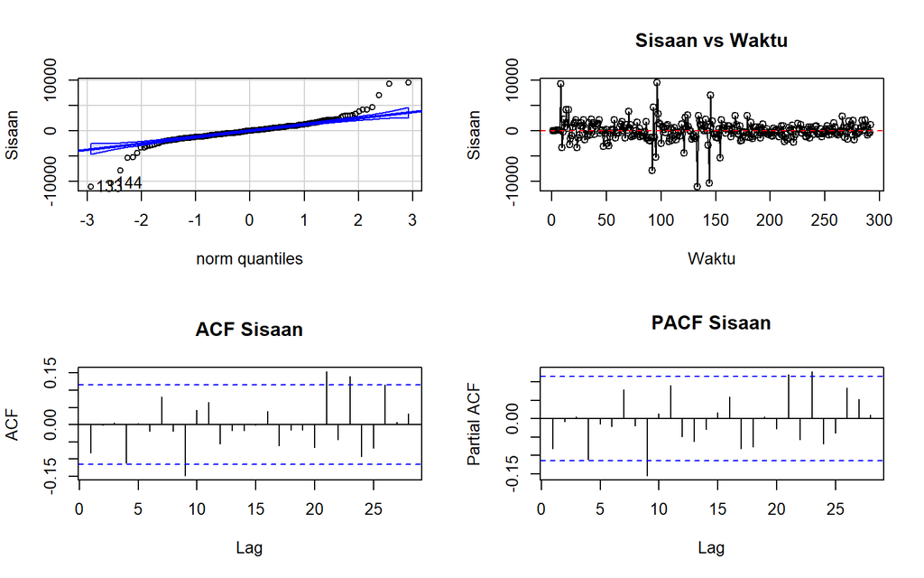

```r
plot(c(1:length(sisaan.f)), sisaan.f, type = "o",
     xlab = "Waktu", ylab = "Sisaan", main = "Sisaan vs Waktu")
abline(h = 0, col = "red", lty = 2)
acf(sisaan.f, lag.max = 28, main = "ACF Sisaan")
pacf(sisaan.f, lag.max = 28, main = "PACF Sisaan")
```

```r
par(mfrow = c(1,1))
```

```r
#1) Sisaan menyebar normal
ks.test(as.numeric(scale(sisaan.f)), "pnorm")
```

```
##
##  Asymptotic one-sample Kolmogorov-Smirnov test
##
## data:  as.numeric(scale(sisaan.f))
## D = 0.1165, p-value = 0.0007218
## alternative hypothesis: two-sided
```

```r
#2) Sisaan saling bebas (fitdf = p + q + Q = 4)
Box.test(sisaan.f, lag = 20, type = "Ljung", fitdf = 4)
```

```
##
##  Box-Ljung test
##
## data:  sisaan.f
## X-squared = 20.56, df = 16, p-value = 0.1961
```

```r
#3) Sisaan homogen
Box.test(sisaan.f^2, lag = 20, type = "Ljung")
```

```
##
##  Box-Ljung test
##
## data:  sisaan.f^2
## X-squared = 46.793, df = 20, p-value = 0.0006266
```

```r
#4) Nilai tengah sisaan sama dengan nol
t.test(sisaan.f, mu = 0, conf.level = 0.95)
```

```
##
##  One Sample t-test
##
## data:  sisaan.f
## t = -0.22022, df = 291, p-value = 0.8259
## alternative hypothesis: true mean is not equal to 0
## 95 percent confidence interval:
##  -247.2876  197.5168
## sample estimates:
## mean of x
## -24.88537
```

Pada model ARIMA(1,0,2)(0,1,1)$_7$, uji Ljung-Box menghasilkan *p-value* sebesar 0.196 yang lebih besar dari 5% sehingga gagal tolak $H_0$ dan **sisaan saling bebas** (asumsi kebebasan sudah terpenuhi, berbeda dengan model sebelumnya). Uji-t menghasilkan *p-value* 0.826 sehingga **nilai tengah sisaan sama dengan nol**. Namun, asumsi normalitas (KS *p-value* 0.0007) dan kehomogenan ragam (*p-value* 0.0006) belum terpenuhi.

### Peramalan

Peramalan dilakukan menggunakan fungsi `forecast()`. Karena model diduga langsung pada data asli (bukan pada data hasil *differencing*), hasil ramalan sudah berada pada skala asli sehingga tidak diperlukan *inverse differencing*. Peramalan dilakukan untuk 73 hari ke depan sesuai panjang data uji.

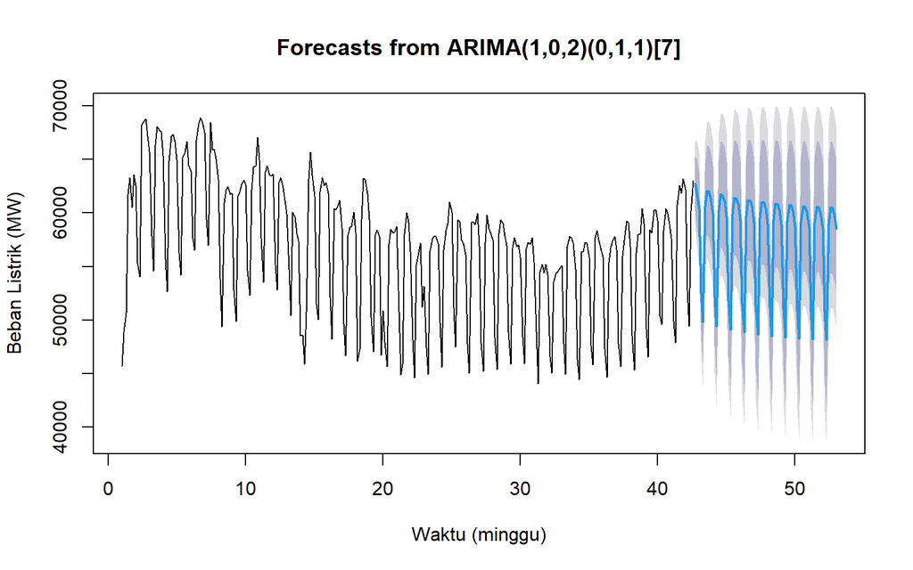

```r
ramalan <- forecast::forecast(model.final, h = length(test))
data.ramalan <- as.numeric(ramalan$mean)
plot(ramalan, xlab = "Waktu (minggu)", ylab = "Beban Listrik (MW)")
```

Berdasarkan hasil plot ramalan di atas, dapat dilihat bahwa ramalan ARIMA(1,0,2)(0,1,1)$_7$ mengikuti pola musiman mingguan (turun pada akhir pekan dan naik pada hari kerja) dan selang kepercayaan melebar seiring bertambahnya peramalan. Selanjutnya, dapat dicari nilai akurasi antara hasil ramalan dengan data uji sebagai berikut.

```r
perbandingan <- matrix(data = c(test, data.ramalan),
                       nrow = length(test), ncol = 2)
colnames(perbandingan) <- c("Aktual", "Hasil Forecast")
perbandingan
```

```
##         Aktual Hasil Forecast
##  [1,] 64122.23       62747.49
##  [2,] 64808.91       61832.54
##  [3,] 63396.25       60381.67
##  [4,] 53037.26       52564.07
##  [5,] 49829.39       49840.54
##  [6,] 61699.84       60612.09
##  [7,] 63351.07       62077.62
##  [8,] 63872.24       61986.03
##  [9,] 62814.99       61390.06
## [10,] 61474.58       59953.77
## [11,] 52948.91       52150.29
## [12,] 49193.07       49440.40
## [13,] 54229.76       60225.14
## [14,] 60390.16       61703.43
```

[output cut: 59 more lines]

```r
# Akurasi
accuracy(data.ramalan, test)
```

```
##                ME    RMSE      MAE      MPE     MAPE
## Test set 2910.202 4910.14 4173.787 4.472676 6.859671
```

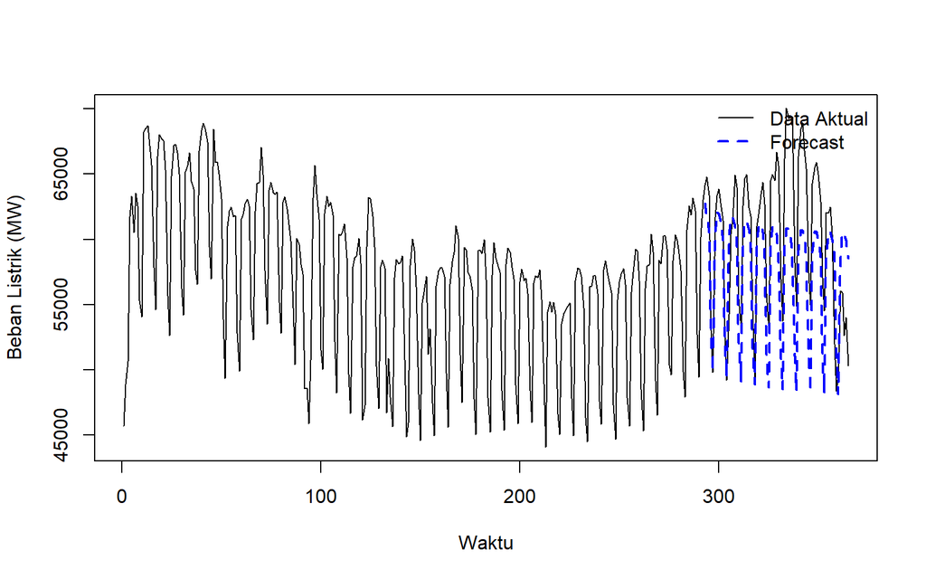

```r
# Plot data aktual dan forecast
ts.plot(beban, col = "black", lty = 1,
        xlab = "Waktu", ylab = "Beban Listrik (MW)")

# Garis forecast
lines((n.train + 1):n, data.ramalan, col = "blue", lty = 2, lwd = 2)
legend("topright",
       legend = c("Data Aktual", "Forecast"),
       col = c("black", "blue"),
       lty = c(1, 2), lwd = c(1, 2), bty = "n")
```

Berdasarkan ukuran akurasi pada data uji, diperoleh RMSE sekitar 4.910 MW, MAE sekitar 4.174 MW, dan MAPE sekitar 6,86%. Artinya, rata-rata ramalan menyimpang sekitar 6,9% dari nilai aktual pada 73 hari ke depan sehingga model cukup baik digunakan untuk meramalkan beban listrik harian. Nilai ME yang positif (sekitar 2.910 MW) menunjukkan bahwa ramalan secara rata-rata sedikit lebih rendah dari nilai aktual. Hal ini wajar karena data uji (Oktober - Desember) mencakup kenaikan beban musim dingin dan penurunan kemungkinan akibat libur akhir tahun yang belum teramati pada data latih yang hanya mencakup satu tahun.

### Perbandingan dengan Model ARIMA Non-Musiman

Sebagai pembanding, dilakukan pemodelan ARIMA biasa, yaitu ARIMA(0,1,1) tanpa komponen musiman, untuk melihat manfaat memodelkan pola mingguan.

```r
model.nonmusiman <- Arima(ts(train), order = c(0,1,1), method = "ML")
lmtest::coeftest(model.nonmusiman)
```

```
##
## z test of coefficients:
##
##     Estimate Std. Error z value Pr(>|z|)
## ma1 0.254431   0.092833  2.7407  0.00613 **
## ---
## Signif. codes:  0 '***' 0.001 '**' 0.01 '*' 0.05 '.' 0.1 ' ' 1
```

```r
# Uji kebebasan sisaan
Box.test(model.nonmusiman$residuals, lag = 20, type = "Ljung", fitdf = 1)
```

```
##
##  Box-Ljung test
##
## data:  model.nonmusiman$residuals
## X-squared = 627.03, df = 19, p-value < 2.2e-16
```

```r
ramalan.nm <- forecast::forecast(model.nonmusiman, h = length(test))

perbandingan.model <- rbind(
  "ARIMA(0,1,1) non-musiman" = accuracy(as.numeric(ramalan.nm$mean), test)[1, c("RMSE", "MAE", "MAPE")],
  "ARIMA(1,0,2)(0,1,1)[7]"   = accuracy(data.ramalan, test)[1, c("RMSE", "MAE", "MAPE")]
)
round(perbandingan.model, 2)
```

```
##                             RMSE     MAE MAPE
## ARIMA(0,1,1) non-musiman 6374.92 4861.84 8.70
## ARIMA(1,0,2)(0,1,1)[7]   4910.14 4173.79 6.86
```

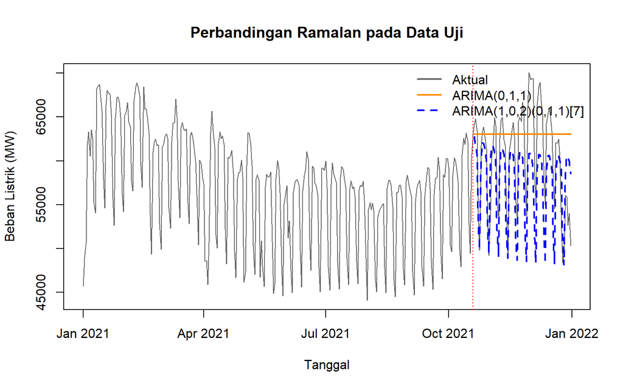

```r
plot(data.energi$Tanggal, beban, type = "l", col = "gray40",
     xlab = "Tanggal", ylab = "Beban Listrik (MW)",
     main = "Perbandingan Ramalan pada Data Uji")
tgl.uji <- data.energi$Tanggal[(n.train + 1):n]
lines(tgl.uji, as.numeric(ramalan.nm$mean), col = "darkorange", lwd = 2)
lines(tgl.uji, data.ramalan, col = "blue", lwd = 2, lty = 2)
abline(v = data.energi$Tanggal[n.train], col = "red", lty = 3)
legend("topright",
       legend = c("Aktual", "ARIMA(0,1,1)", "ARIMA(1,0,2)(0,1,1)[7]"),
       col = c("gray40", "darkorange", "blue"), lty = c(1, 1, 2), lwd = 2, bty = "n")
```

Model ARIMA(0,1,1) tanpa komponen musiman menghasilkan ramalan berupa garis mendatar yang tidak dapat menirukan pola naik turun mingguan, dan sisaannya masih memiliki autokorelasi yang sangat kuat (uji Ljung-Box *p-value* $< 2.2 \times 10^{-16}$). Model tersebut juga memiliki akurasi yang lebih rendah (RMSE sekitar 6.375 MW dan MAPE sekitar 8,70%) dibandingkan model musiman (RMSE sekitar 4.910 MW dan MAPE sekitar 6,86%). Hal ini menunjukkan bahwa pola musiman mingguan pada data beban listrik perlu dimodelkan secara eksplisit.